# The Logic of Logistic Regression

*Joseph Catanzarite* *10/27/2020*

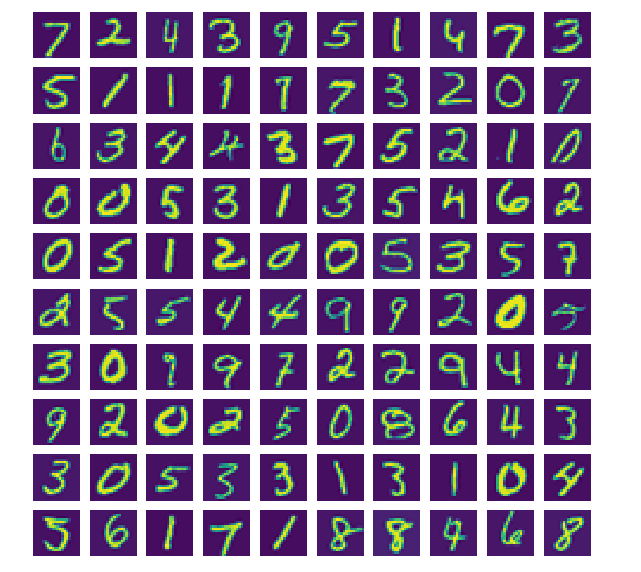

```
*Source: Medium/AnalyticsVidhya*
```

```python
from IPython.display import Image
display(Image("rgb_mnist_image.png"))
print('*Source: Medium/AnalyticsVidhya*')
```

## A word to the student:

*This might just be the most important lesson in machine learning you will ever see. Why? Because in the process of learning about Logistic Regression, you will encounter several powerful techniques and ideas that are the backbone of the entire field of AI (artificial intelligence). One of these ideas is the method of Gradient Descent -- which is the key to all of deep learning with neural networks.*

*As you progress along your machine learning journey, you'll notice that ideas you encountered in this lesson will recur again and again. Even if you don't completely grasp all the ideas today, you'll get a solid introduction, and your understanding will grow with time. These ideas will become familiar and cherished tools that you will use to crack open one machine learning problem afer another.*

Sections **1 - 3** of this notebook present a concise introduction to Logistic Regression and its application to binary classification problems. Section **4** is a **Wrap-up and Summary**, and Section **5** is an **Assessment** to be done in a group setting. The **References** section lists a few helpful resources.

The **Appendix** contains further discussion of classification problems, and of the assumptions, strengths and weaknesses of the Logistic Regression classifier.

The **Supplement: A Complete Introduction to Logistic Regression** extends and completes our discussion, for those who want to go further. Section **S.1** **The Mathematics of Logistic Regression** explains how a Logistic Regression model is trained. In the process, we encounter several key concepts in Machine Learning: the **Maximum Likelihood** Method, the **Binary Cross-Entropy** function, and the Method of **Gradient Descent**. In section **S.2** we show how to implement the ideas of Section **S.1** to build our own Logistic Regression Classifier in Python. Finally, in Section **S.3**, we apply our Logistic Regression Classifier to an instructive Case Study of the **Pima Indians Diabetes Dataset**.

## Key Objectives

After this lesson you will:

1. Be able to explain what is a binary classification problem.
2. Be able to explain the MNIST digit classification problem
3. Be able to define the terms `feature`, `outcome`, and `class probability`, for a binary classification problem.
4. Understand what is the `hypothesis` in a linear model of the data
5. Understand what is the `signal` in the data, given a `hypothesis`
6. Be able to compute the `logistic function` and explain how it relates to probability
7. Be able to compute the `signal` and the `class probability` for a data point, given a `hypothesis`
8. Be able to describe qualitatively how `logistic regression` works to solve classification problems.
9. Be able to solve a binary classification problem with continuous features using sklearn's `logistic regression` model
10. Be able to explain the advantages of `logistic regression` over `linear regression` for binary classification problems with continuous features.

## 1. Why should we learn Logistic Regression?

In a nutshell, `logistic regression` is a supervised classification technique which,  
given a set of `examples` and their `features` and `class labels`,  
learns to predict `class probabilities` for new examples.  
From the `class probabilities`, we can predict `class labels` for the new examples.

- Logistic Regression is one of the most widely used machine learning algorithms in the world.
- Logistic regression is one of the "go to" methods to solve **classification problems** in Machine Learning; it is a tool that should be in every data scientists tool box.

## 2. Binary classification with continuous feature(s)

For example we could observe whether or not a group of individuals has Diabetes ($0$ or $1$), and collect numerical data such as blood presssure, glucose level, body mass index, age, etc. from each individual in the group. We could then build a model to try to predict whether a person has diabetes or not, given their data for this set of features.

In **Section S.3** of the **Supplementary Material** below, we present a **Case Study** along these lines, in which we analyze the **Pima Indians Diabetes Data Set**

In this section we develop an approach to binary classification problems with continuous features.

Suppose we have a sample of data points, each with a vector of features $x$ and a binary label $y$

We start with the notion that there is a **signal** $z$ which is linear in the feature(s), and which may help predict the **outcome**:  
$z = w^{T}x + b$, where

- $x$ is a column vector of features (real numbers),
- $w$ is a column vector of associated weights (real numbers),
- $w^{T}$ is the transpose of $w$, so it's a row vector, and
- $b$ is a constant bias (a real number).

The problem of classification can be broken down as follows:

- Find a **model**, i.e. a way to compute the **outcome** as a function of the **features**, given a **hypothesis** $(w,b)$ and a data point $x$
- Identify the best **hypothesis** $(w,b)$ i.e. the particular $w$ and $b$ that gives the best predictions for the outcomes.

*Question*  
Given a vector of feature values $x$, the associated vector of weights $w$ and the bias $b$:  
Is the signal $z=w^{T}x + b$ a vector or a scalar?

In **Section 3** we present a **Case Study** in which we first develop a simple toy binary classification problem, and then solve it by two different methods:

- Linear Regression (which should already be familiar)
- Logistic Regression

In the process, we'll introduce Logistice Regression and explain how it is used in classification problems. You will see how Linear and Logistic Regression differ, and what makes Logistic Regression a better tool for binary classification problems.

## 3. Case Study: MNIST digit classification in one dimension

The MNIST data set is a set of $70,000$ grayscale images of the digits $0$ through $9$, with roughly equal numbers of examples of each digit.  
The images are $28$x$28$ pixels, so each image has $28^2=784$ pixels, which can be considered as the features  
In a grayscale image, the pixels each have values ranging from $0$ to $255$, where $0$ is darkest, and $255$ is brightest  
The pixels defining the digit are bright, while background pixels are dark.

We'll separate the MNIST images into two classes:

- class $1$: the `digit is a $1$`, and
- class $0$: `digit is not a $1$`

Digits with shorter "lengths" have fewer bright pixels, so we expect their images to have lower mean pixel values than images of digits with longer "lengths".

The $1$ generally has the shortest "length" of all the digits, and thus the fewest bright pixels

So we expect images of the digit $1$ to have lower `average pixel value` than images of all other digits

By representing each image by its`average pixel value`, we reduce the $784$ dimensional set of features to one dimension. This is an example of **feature engineering**. In this case we created the new feature because we expect it to help separate the two classes.

Next, we'll test out the idea: we'll build a classifier that predicts whether or not an image is a $1$, given only its `average pixel value`.

*Question* Looking at the histogram below, can you think of other useful ways that we could have reduced the image to a single number?

## 3.1 Get the MNIST data set, explore it a bit, and prepare the data for modeling

```python
# set up environment, import packages we'll need
import numpy as np
import matplotlib as mpl
import matplotlib.pyplot as plt
%matplotlib inline
import pandas as pd
import seaborn as sns
import random
from sklearn.preprocessing import StandardScaler
from sklearn.linear_model import LogisticRegression
from sklearn.linear_model import LinearRegression
from sklearn.model_selection import cross_validate
from sklearn.model_selection import train_test_split
from sklearn import metrics
from sklearn.datasets import fetch_openml
from sklearn.metrics import classification_report
pd.options.display.max_columns = None
pd.options.display.max_rows = None
np.random.seed(42)
```

```python
mnist = fetch_openml('mnist_784', version=1)
mnist.keys()
```

```
dict_keys(['data', 'target', 'frame', 'categories', 'feature_names', 'target_names', 'DESCR', 'details', 'url'])
```

```python
# each MNIST image has 28**2 = 784 pixels, which are considered features
X, y = mnist["data"], mnist["target"]
print(X.shape)
```

```
(70000, 784)
```

### Let's look at an example image for each digit, along with its mean pixel value

```python
# function to plot an image
def plot_digit(data):
    image = data.reshape(28, 28)
    plt.imshow(image,cmap="gray",interpolation="nearest")
```

```
39.661989795918366
```

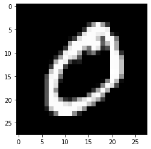

```python
plot_digit(X[y=='0'][0])
print( np.mean(X[y=='0'][0]))
```

```
21.855867346938776
```

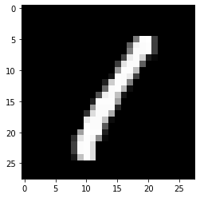

```python
plot_digit(X[y=='1'][0])
print( np.mean(X[y=='1'][0]))
```

```
37.75637755102041
```

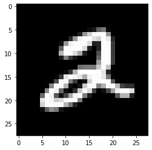

```python
plot_digit(X[y=='2'][0])
print( np.mean(X[y=='2'][0]))
```

```
45.74872448979592
```

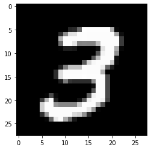

```python
plot_digit(X[y=='3'][0])
print( np.mean(X[y=='3'][0]))
```

```
24.799744897959183
```

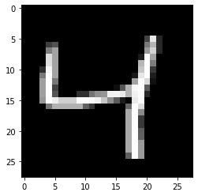

```python
plot_digit(X[y=='4'][0])
print( np.mean(X[y=='4'][0]))
```

```
35.108418367346935
```

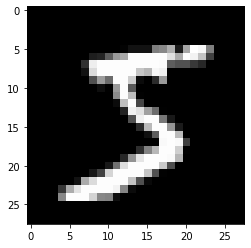

```python
plot_digit(X[y=='5'][0])
print( np.mean(X[y=='5'][0]))
```

```
36.27933673469388
```

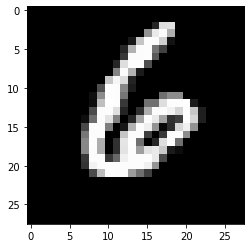

```python
plot_digit(X[y=='6'][0])
print( np.mean(X[y=='6'][0]))
```

```
32.265306122448976
```

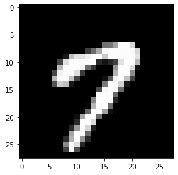

```python
plot_digit(X[y=='7'][0])
print( np.mean(X[y=='7'][0]))
```

```
34.57397959183673
```

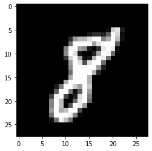

```python
plot_digit(X[y=='8'][0])
print( np.mean(X[y=='8'][0]))
```

```
29.60969387755102
```

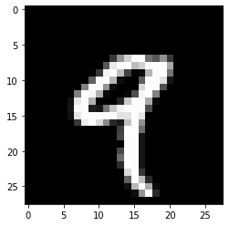

```python
plot_digit(X[y=='9'][0])
print( np.mean(X[y=='9'][0]))
```

### Histogram of pixel values in the above image

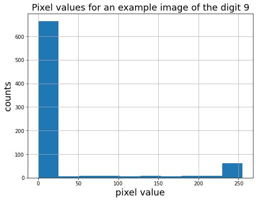

```python
fig, (ax) = plt.subplots(1, 1,figsize=[8,6])
plt.hist(X[y=='9'][0]);
plt.grid()
plt.xlabel('pixel value',FontSize=18)
plt.ylabel('counts',FontSize=18)
plt.title('Pixel values for an example image of the digit 9',FontSize=18);
```

```python
# calculate the mean pixel value for each image
X = np.mean(X, axis=1)
print(X.shape,y.shape)

# convert labels to integers
z = y.astype(int)
```

```
(70000,) (70000,)
```

### Histogram of the mean pixel value for all images in each digit class

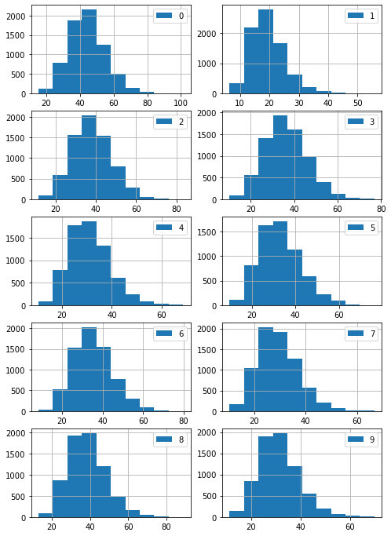

```python
fig = plt.figure(figsize=(8,12))
count=1
for digit in np.unique(y):
    idx = y==digit
    ax=plt.subplot(5,2,count)
    ax.hist(X[idx],label=digit)
    ax.legend()
    ax.grid()
    count+=1
```

### Put the data in a list with an array of mean pixel values for each digit class

```python
data = [X[y==i] for i in np.unique(y) ]
```

### Box plot

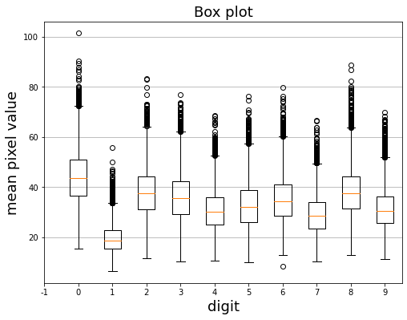

```python
fig, ax = plt.subplots(figsize=[8,6])

# build a box plot
ax.boxplot(data)

# add title and axis labels
ax.set_title('Box plot',fontsize=18)
ax.set_xlabel('digit',fontsize=18)
ax.set_ylabel('mean pixel value',fontsize=18)

# add x-tick labels
xticklabels = [-1]+list(np.unique(z))+[10]
ax.set_xticks(list(np.unique(z))+[10])
ax.set_xticklabels(xticklabels)

# add horizontal grid lines
ax.yaxis.grid(True)
```

### Violin plot

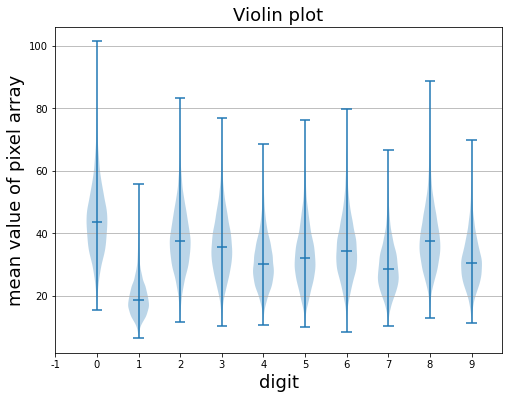

```python
fig, ax = plt.subplots(figsize=[8,6])

# build a violin plot
ax.violinplot(data, showmeans=False, showmedians=True)

# add title and axis labels
ax.set_title('Violin plot',fontsize=18)
ax.set_xlabel('digit',fontsize=18)
ax.set_ylabel('mean value of pixel array',fontsize=18)

# add x-tick labels
xticklabels = [-1]+list(np.unique(z))+[10]
ax.set_xticks(list(np.unique(z))+[10])
ax.set_xticklabels(xticklabels)

# add horizontal grid lines
ax.yaxis.grid(True)
```

### Correct for class imbalance

```python
# Note that classes are imbalanced
print(len(y[y!='1']))
print(len(y[y=='1']))
```

```
62123
7877
```

```python
# Correct for class imbalance by downsampling,
#     so that there are equal numbers of examples in classes '1' and 'not 1'
# Set labels to 1 for class '1' and to zero for class 'not 1'
inds_not_1 = random.sample(range(len(y[y!='1'])), len(y[y=='1']))
y_not_1 = y[y!='1'][inds_not_1]
y_not_1 = np.array(['0' for x in range(len(y_not_1))])
X_not_1 = X[y!='1'][inds_not_1]
X_1 = X[y=='1']
y_1 = y[y=='1']
y = np.concatenate((y_1,y_not_1),axis=0)
# reverse direction of X so that logistic curve bends upward to the right
X = -np.concatenate((X_1,X_not_1),axis=0)
print(X.shape,y.shape)
```

```
(15754,) (15754,)
```

### Split data into train, valid, and test sets

```python
# split data into train and valid sets
x_train, x_valid, y_train, y_valid = train_test_split(X,y,random_state = 42)

# split valid set into a valid set and a test set
n_test = 100
x_valid, x_test, y_valid, y_test = train_test_split(x_valid,y_valid,test_size=n_test,random_state = 42)
```

## 3.2 Build a classifier with ordinary least squares regression

One approach would be to fit the **signal** $z$ directly to the label values 0 and 1, via least squares.

We can make predictions with our least squares model by applying a threshold of $0.5$ and predicting the positive class for all data points with $z > 0.5$ and the negative class for all data points with $z \le 0.5$.

So yes, we can use least squares regression to solve binary classification problems, but as we'll see later, it's not optimal.

*Question:*  
Looking at the plot below, do you think the regression line is a good model of the data?  
Why or why not?

### Fit linear regression model

```python
# fit logistic regression model
clf = LinearRegression()
clf.fit(x_train[:,None],y_train)
```

```
LinearRegression()
```

### Predict labels

```python
# predict labels and probabilities
y_pred = clf.predict(x_test[:,None])
y_pred_label = y_pred > 0.5
```

### Plot data, predictions, and linear regression fit

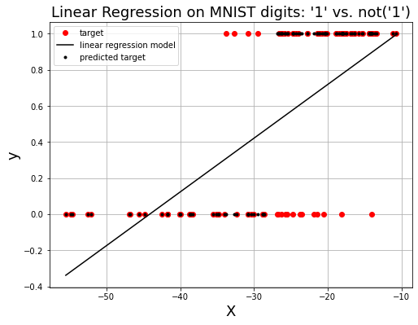

```python
# indices for sorting test data by x value
idx=np.argsort(x_test)
# convert labels to integers
y_test = y_test.astype(int)
fig, (ax) = plt.subplots(1, 1,figsize=[8,6])
ax.plot(x_test[idx],y_test[idx],'ro',label='target')
ax.plot(x_test[idx],y_pred[idx],'k-',label='linear regression model')
ax.plot(x_test[idx],y_pred_label[idx],'k.',label='predicted target')
ax.yaxis.grid()
ax.xaxis.grid()
ax.set_xlabel('X',fontsize=18)
ax.set_ylabel('y',fontsize=18)
ax.set_title('Linear Regression on MNIST digits: \'1\' vs. not(\'1\')',fontsize=18)
ax.legend(loc='upper left');
```

### Classification report

```python
target_names = [0,1]
print(classification_report(y_test,y_pred_label))
```

```
              precision    recall  f1-score   support

           0       0.89      0.72      0.80        47
           1       0.79      0.92      0.85        53

    accuracy                           0.83       100
   macro avg       0.84      0.82      0.83       100
weighted avg       0.84      0.83      0.83       100
```

### Confusion matrix

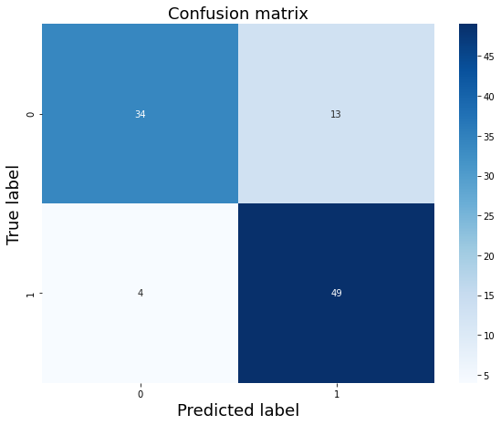

```python
# confusion matrix
cnf_matrix = metrics.confusion_matrix(y_test, y_pred_label)

# class labels
class_names=[0,1]

# set up the figure
fig, (ax) = plt.subplots(1, 1,figsize=[8,6])
tick_marks = np.arange(len(class_names))
plt.xticks(tick_marks, class_names)
plt.yticks(tick_marks, class_names)

# plot the confusion matrix
sns.heatmap(pd.DataFrame(cnf_matrix), annot=True, cmap= 'Blues',fmt='g')
ax.xaxis.set_label_position("bottom")
plt.tight_layout()
plt.title('Confusion matrix',FontSize=18)
plt.ylabel('True label',FontSize=18)
plt.xlabel('Predicted label',FontSize=18)
```

## 3.3 Logistic regression: a probability-based approach to classification

What if we regard each **outcome** (zero or one) as a noisy, rounded-off estimate of the **class probability**, .i.e. the probability of being in the positive class?  
I.e. if the class probability of an example is $\le \frac{1}{2}$, it would round off to 0, and the example would be in class $0$  
And if the class probability of an example is $> \frac{1}{2}$, it would round it off to 1, and the example would be in class $1$

We observe only the **feature(s)** and **outcomes** of the examples in the training set, and we want to solve for the underlying **class probability distribution** that is consistent with the observed **outcomes**.

*Quick Exercise: "Logistic Regression by hand*  
Looking at a graph showing the outcomes vs. the feature, can you draw a curve that fits the data better than the regression line, and looks like probabilities? Take a few minutes to try.  
Congratulations, you have just done a qualitative version of logistic regression on the data!

Can we find a way to map the **signal** $z$ directly to the **class probabilities**?

### The logistic function

It turns out that there is a special function that can do just the sort of mapping that we have in mind!  
It's called the logistic (or sigmoid) function:  
Given a signal $z$ ranging over the real numbers in $[-\infty,+\infty]$

$\sigma(z) = \frac{1}{1+e^{-z}}$  
$\sigma$ maps the real numbers onto the the interval $[0,1]$, thus turning them into probabilities!

*Questions*

- What happens to $e^{-z}$ as z goes to $-\infty$?
- What happens to $e^{-z}$ as z goes to $+\infty?$
- What happens to $e^{-z}$ as z goes to $0$?

*Exercise*  
Do the following computations by hand:

- $\sigma(-\infty)=$?
- $\sigma(+\infty)=$?
- $\sigma(0)=$?

### Visualizing the logistic function

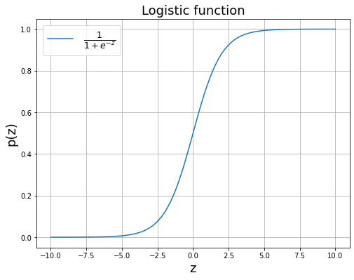

```python
# plot the logistic function
z = np.linspace(-10,10,101)
p = 1./(1.+ np.exp(-z))
plt.figure(figsize=(8, 6))
plt.plot(z,p,label=r'$\frac{1}{1+e^{-z}}$')
plt.title('Logistic function',FontSize=18)
plt.xlabel('z',FontSize=18)
plt.ylabel('p(z)',FontSize=18)
plt.grid()
plt.legend(loc=2, prop={'size': 18});
```

### Logistic regression

Logistic regression begins with the assumption that there is a linear **signal** $z = w^{T}x + b$ in the data  
that can be mapped to a probability via the logistic function.

$prob(y=1|z) = \sigma(z) = \frac{1}{1+e^{-z}} = \frac{1}{1+exp(-w^{T}x - b)}$

Here, the symbol $|$ is interpreted as "given".

The notation $prob(y=1|z)$ denotes the **class probability**, which is the probability that the outcome is the positive class **given** $z$.

The logistic regression approach to classification:  
Given observations of the **feature(s)** and the $0$ or $1$ **outcomes**, we want to find a **hypothesis** (values of the weights $w$ and the bias $b$) that generates **class probabilities** that are as close as possible to the observed distribution of outcomes.

This is a nonlinear problem which, unlike linear regression, has no closed form solution.  
In the **Supplement** section, we will develop and implement a powerful and effective method for solving problems of this kind.

For now, we'll use scikit-learn's `LogisticRegression` to obtain the solution.  
Evidently, the logistic regression model more closely resembles the outcome distribution than does the linear regression line.  
A key advantage of logistic regression is that it gives **class probabilities** for each example, which measure our confidence in each classification.

### Fit logistic regression model

```python
# fit logistic regression model
clf = LogisticRegression(random_state=42)
clf.fit(x_train[:,None],y_train)
```

```
LogisticRegression(random_state=42)
```

### Predict labels and probabilities

```python
# predict labels and probabilities
y_pred = clf.predict(x_test[:,None])
y_pred_proba = clf.predict_proba(x_test[:,None])
```

### Plot data, predictions, and logistic regression fit

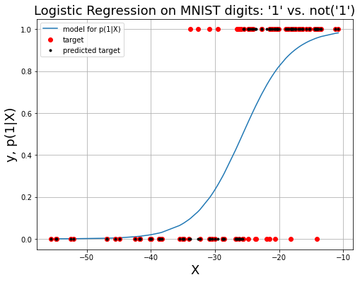

```python
# indices for sorting test data by x value
idx=np.argsort(x_test)
y_test=y_test.astype(int)
y_pred=y_pred.astype(int)
fig, (ax) = plt.subplots(1, 1,figsize=[8,6])
ax.plot(x_test[idx],y_pred_proba[idx,1],label='model for p(1|X)')
ax.plot(x_test[idx],y_test[idx],'ro',label='target')
ax.plot(x_test[idx],y_pred[idx],'k.',label='predicted target')
ax.yaxis.grid()
ax.xaxis.grid()
ax.set_xlabel('X',fontsize=18)
ax.set_ylabel('y, p(1|X)',fontsize=18)
ax.set_title('Logistic Regression on MNIST digits: \'1\' vs. not(\'1\')',fontsize=18)
ax.legend(loc='upper left');
```

### Classification report: 82% Accuracy

```python
target_names = ['0','1']
print(classification_report(y_test,y_pred))
```

```
              precision    recall  f1-score   support

           0       0.81      0.81      0.81        47
           1       0.83      0.83      0.83        53

    accuracy                           0.82       100
   macro avg       0.82      0.82      0.82       100
weighted avg       0.82      0.82      0.82       100
```

### Confusion matrix

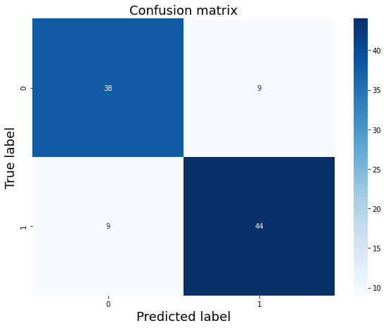

```python
# confusion matrix
cnf_matrix = metrics.confusion_matrix(y_test, y_pred)

# class labels
class_names=[0,1]

# set up the figure
fig, (ax) = plt.subplots(1, 1,figsize=[8,6])
tick_marks = np.arange(len(class_names))
plt.xticks(tick_marks, class_names)
plt.yticks(tick_marks, class_names)

# plot the confusion matrix
sns.heatmap(pd.DataFrame(cnf_matrix), annot=True, cmap= 'Blues',fmt='g')
ax.xaxis.set_label_position("bottom")
plt.tight_layout()
plt.title('Confusion matrix',FontSize=18)
plt.ylabel('True label',FontSize=18)
plt.xlabel('Predicted label',FontSize=18);
```

### ROC curve and AUC metric

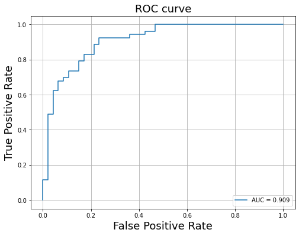

```python
FPR, TPR, _ = metrics.roc_curve(y_test, y_pred_proba[:,1],pos_label=1)
AUC = metrics.roc_auc_score(y_test, y_pred_proba[:,1])
fig, (ax) = plt.subplots(1, 1,figsize=[8,6])
plt.plot(FPR, TPR, label=f'AUC = {AUC:.3}')
plt.legend(loc='lower right')
plt.title('ROC curve',FontSize=18)
plt.xlabel('False Positive Rate',FontSize=18)
plt.ylabel('True Positive Rate',FontSize=18)
plt.grid()
plt.show()
```

## 4. Wrap-up and Summary

We solved the MNIST classification problem with both linear regression and logistic regression.  
In general, logistic regression is better for classification, though in this case we got a slightly better result with linear regression.

The reasons are

- Logistic regression is more interpretable since it gives class probabilities
- Logistic regression is less sensitive to imbalanced data
- Logistic regression is easily extended to multiple class problems
- On the other hand, Linear regression cannot generally be used for problems with more than two classes.

In this lesson we learned two approaches to solve a simple 1-dimensional binary classification problem with the MNIST data set

- Linear Regression
- Logistic Regression

We also learned

- The logistic function and how to compute it
- An advantage of using Logistic Regression over Linear Regression is that it yields class probabilities for its predictions
- How to use the sklearn library to solve simple binary classification problems

## 5. Assessment

### Key Concepts

- binary classification problem
- hypothesis, weights and bias
- signal in the data
- conditional probability of the positive class given the data and a model hypothesis
- logistic function
- logistic regression approach to classification

### Group exercise

1. (10 min) Split the group into teams of 2 or 3 students. Each team assigns itself 2 or 3 of the Key Concepts to review. Negotiate the assignments so that each of the Key Concepts is assigned to one of the teams. During this review phase, you can refer to the presentation.
2. (5 min) Now *without* looking at the presentation, each team works together to write down their best brief explanation of the assigned Key Concepts.
3. (5 min) Reconvene the group and have each team present their Key Concept explanations to the group.

## References:

Books

- Hands On Machine Learning with Scikit-Learn, Keras & TensorFlow, 2nd. ed., Aurelien Geron, Chapter 4
- Learning From Data, Prof. Yaser Abu-Mostafa, et al , Chapter 3

Videos

- Logistic Regression, Maximum Likelihood, and Gradient Descent, Prof. Yaser Abu-Mostafa, https://www.youtube.com/watch?v=qSTHZvN8hzs&hd=1  
  Andrew Ng's Coursera Machine Learning videos
- Lecture 6.1, https://www.youtube.com/watch?v=-la3q9d7AKQ
- Lecture 6.2, https://www.youtube.com/watch?v=t1IT5hZfS48,
- Lecture 6.3, https://www.youtube.com/watch?v=F_VG4LNjZZw

Blog posts

- Understanding Logistic Regression in Python, by Avinash Nalini https://www.datacamp.com/community/tutorials/understanding-logistic-regression-python
- Why Linear Regression is not suitable for Classification https://jinglescode.github.io/2019/05/07/why-linear-regression-is-not-suitable-for-classification/

## A.1 The variety of classification problems

Classes can be

- binomial (2 classes)
- multinomial (K classes, with K > 2)
- ordinal (K > 2 classes, with ordered class values, such as `Good`, `Better`, `Best`)

Predictors (features) can be

- discrete (also called categorical)
- continuous
- a mix of discrete and continuous

Class labels can be

- single: each example has only one class label, as in `has heart disease` and `doesn't have heart disease`
- multiple: each example may have more than one class label, as a scene in a satellite image can contain farmland, a residential area, a river, and/or clouds.

### Examples of classification problems that can be addressed with logistic regression

- Image Data: lung cancer detection
- Text Data: sentiment classification of movie reviews
- Tabular Data:  
  -- Predict the probability that a person will have a heart attack given blood pressure, age, weight  
  -- Fraud detection in bank transaction data  
  -- Predict the quality of a wine from physico-chemical measurements

*Exercise*: Do one of the following  
Spend 5 minutes on Google and find an example of A. A multi-class, single label problem with discrete (categorical) features  
B. A multi-class, multiple label problem  
C. A multi-class problem with ordinal labels

#### In this lesson we'll focus on binary (two-class) classification problems with continuous features

## A2. Assumptions of Logistic Regression

- there two distinct classes, and each example belongs to exactly one of these classes
- examples are independent
- features are not too highly correlated with each other
- the decision boundary is linear, i.e. the **signal** that is used to separate the classes is linear in the features
- the sample size is large relative to the number of features
- there are no outliers in the data

## A3. Strengths and weaknesses of Logistic Regression

### Advantages:

- yields class probabilities as well as class predictions
- easy to implement
- training and inference are fast
- the model is *interpretable* because the coefficients (weights) directly measure the feature importances
- can be extended to multi-class, or multi-label problems

### Disadvantages

- assumes that the relevant **signal** that separates the classes is linear in the features
- cannot handle nonlinear problems where the functional form of the **signal** is unknown
- tends to overfit in high-dimensional data sets

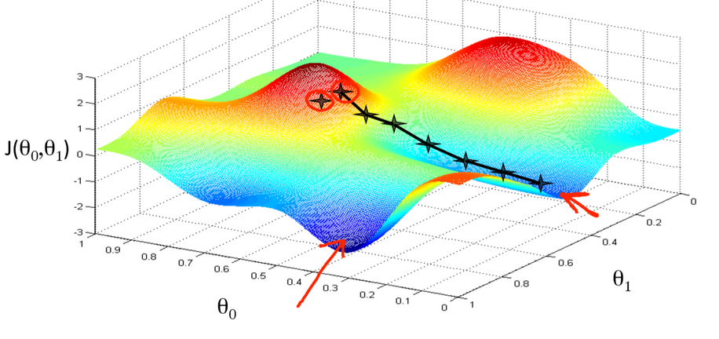

```
*Source: HackerNoon*
```

```python
display(Image("gradient_descent.png"))
print("*Source: HackerNoon*")
```

## Supplement: A complete introduction to Logistic Regression

## Key Objectives

After this lesson you will:

1. Understand what the `likelihood function` tells us, and be able to compute it from your data, given a `hypothesis`
2. Understand and be able to explain the `method of maximum likelihood`, and its role in `logistic regression`
3. Understand and be able to explain how `gradient descent` works, in a qualitative way
4. Be able to compute the `cross-entropy loss function`, and explain its role in computing the parameter updates for `gradient descent`
5. Know how to `implement logistic regression` in Python
6. Be able to `apply logistic regression` to a binary classification problem with continuous features

## S.1 Theory: The Mathematics of Logistic Regression

## S.1.1 The Maximum Likelihood Method

The maximum likelihood method offers a way to carry out the logistic regression approach.  
We compute the "likelihood" of the observed data, given a hypothesis (weights and bias).  
We then find the hypothesis -- specific values $(w,b)$ -- that maximizes the likelihood of observing the data that we got.

Sounds reasonable, right?  
But you might raise a number of questions:

- What do we mean by the "likelihood"?
- How can we compute the "likelihood"?
- How can we maximize the "likelihood"?

#### Likelihood of a data point

Suppose we observe a data point, an outcome $y$ that is either $0$ or $1$, along with its associated feature $x$  
As we have seen, given a hypothesis $(w,b)$ we can predicts the positive class probability $p$ for this data point

$L \equiv p^{y}(1-p)^{1-y}$  
Keep in mind that, although for simplicity it is not explicitly shown, both $p$ and $L$ are functions of the data and the hypothesis:  
$p = p(x,w,b)$ and $L = L(x,w,b)$

*Exercise*  
Suppose a hypothesis predicts a positive class probability of $p=0.7$ for a data point.

Compute the likelihood $L$ of the data point for each possible outcome:

- $y=1$, then $L = $ ?
- $y=0$, then $L = $ ?

If we observe an outcome of $y=1$ and our model predicts a positive class probability of $0.7$, then the hypothesis is relatively good, since it is consistent with the observed data  
On the other hand, if the model had predicted a positive class probability of $0.3$ then we'd say the hypothesis is bad, because it's inconsistent with the observed data.

#### The likelihood function

$\mathcal{L}(X,w,b) \equiv \Pi_{i=1}^{m} L_{i} = \Pi_{i=1}^{m} p_{i}^{y_{i}}(1-p_{i})^{1-y_{i}}$ where $m$ is the number of data points.

Again, keep in mind that $p$ is a function of the data and the hypothesis: $p = p(x,w,b)$

*Question*  
Is the likelihood function a vector or a scalar?

In a nutshell, the maximum likelihood method seeks to find the **hypothesis that is most consistent with the data**, i.e. the $(w,b)$ that maximizes the likelihood function $\mathcal{L}(X,w,b)$.

We note that maximizing the likelihood is the same as maximizing the log-likelihood, which simplifies the product into a sum

$log(\mathcal{L}(w,b)) = \sum_{i=1}^{m} (y_{i}log(p_{i}) + (1-y_{i})log(1-p_{i}))$

So log-likelihood is a quantitative measures of how much we should trust our hypothesis. The higher the log-likelilhood, the more consistent the data is with the hypothesis and therefore more believable is the hypothesis.

## S.1.2 The cross-entropy loss function

*Maximizing* the log-likelihood function is equivalent to *minimizing* the cross-entropy loss function $\mathcal{J}(w,b)$, defined as

$\mathcal{J}(w,b) \equiv -\frac{1}{m}\sum_{i=1}^{m} (y_{i}log(p_{i}) + (1-y_{i})log(1-p_{i}))$

*Questions*

- Can $y_{i}log(p_{i})$ or $(1-y_{i})log(1-p_{i})$ ever be negative?
- What is the value of the term $y_{i}log(p_{i}) + (1-y_{i})log(1-p_{i})$ in the cross-entropy function for a data point $i$ whose predicted probability $p_{i}$ exactly matches the outcome $y_{i}$? Hint: separately consider the possible outcomes $y_{i}=1$ and $y{i}=0$

The cross-entropy loss function is a measure of the error between the *predicted* probability distribution of the outcomes matches the *actual* distribution of the outcomes. Values significantly less than $1$ are are generally good.

So far so good. We have a way to measure the error in our predictions -- the cross-entropy loss. Just as we did for least squares regression, we know what to do next: find the parameters that minimize the error! In other words, we have to find the hypothesis $(w,b)$ that minimizes the cross-entropy loss.

So we know where we're going. But how do we get there?  
Next we will see that the Method of Gradient Descent can offer us a prescription for how to "get to the bottom of things"!

## S.1.3 The Method of Gradient Descent

In a nutshell: the **Method of Gradient Descent** says that to find the minimum of a function you start with random values of the parameters -- in our case, the weights $w$ and the bias $b$ -- and then iteratively adjust the parameters so as to take small steps in the "downhill" direction, until you reach the lowest point.

But how should we adjust the parameters? It turns out that the adjustment to a parameter should be proportional to the **negative partial derivative of the loss function with respect to that parameter**. This can be shown using calculus, but is beyond the scope of this lesson, so we'll have to accept it on faith.

So here is the prescription for the "Method of Gradient Descent":

Repeat until convergence: {

$w_{j} \leftarrow w_{j} - \alpha \frac{\partial \mathcal{J}(w,b)}{\partial w_{j}}$  
$b \leftarrow b - \alpha \frac{\partial \mathcal{J}(w,b)}{\partial b}$  
where $\alpha$ is a positive constant called the learning rate.

}

In the next section we will build a **Logistic Regression Solver** that implements the **Method of Gradient Descent** to minimize the **cross-entropy loss function**. From the resulting $(w,b)$ we can then compute the **positive class probability distribution** that is closest to the distribution of outcomes found in the data.

## S.2 Implementation: build a logistic regression classifier from scratch

In this section we'll use a "divide and conquer" strategy to build the logistic regression model from its essential pieces:

- The main function `logistic_regression` implements logistic regression via gradient descent

The required helper functions are

- `logistic` computes the logistic function
- `cross_entropy` computes the cross entropy loss function
- `grad_loss` computes the gradient of the loss function with respect to the weights and bias
- `predict_y` predicts class probabilities and labels for new examples

```python
def cross_entropy(y, y_proba):
    '''
     Compute the cross-entropy loss function, which is appropriate for binary classification problems
     Inputs:
        y: column vector with true label (1 or 0) for each example
        y_proba: column vector with predicted probability of class 1 for each example
     Output:
        cross_entropy loss: scalar, mean of NLL over all examples
        negative_log_loss is negative log likelihood for each example
    '''

    # compute negative log loss (cross-entropy loss)
    negative_log_loss = -(y*np.log(y_proba) + (1. - y)*np.log(1. - y_proba))
    return np.mean(negative_log_loss)
```

```python
def logistic(z):
    '''
    Compute the logistic function
    Input:
       z: a vector of real numbers
    Output:
       y_proba: logistic function of z: a vector of probabilities, real numbers on the interval [0,1]
    '''

    # constants
    eps = 1.e-15

    # logistic function
    y_proba = 1./(1. + np.exp(-z))

    # Fix y_proba overflow/underflow problem
    y_proba[y_proba >= 1.] = 1. - eps
    y_proba[y_proba <= 0.] = eps
    return y_proba
```

```python
def predict_y(X, w, b):
    '''
    Predict the probability of the positive class,
    based on a hypothesis (w,b) for a matrix X of input examples
    Inputs:
       X: input data matrix -- 1 column of feature values for each example
       w: weights -- column vector, length = number of features
       b: bias, a scalar
     Outputs:
       y_proba: a column vector, length = number of examples
    '''

    # constants
    max_log = 40.

    # Compute z, a row vector with length = number of examples
    z = w.T@X + b
    # Fix the z overflow/underflow problem
    z[z>max_log] = max_log
    z[z<-max_log] = -max_log

    # predicted probability of the positive class
    y_proba = logistic(z).T
    return y_proba
```

```python
def grad_loss(X, y, w, b):
    '''
    Compute the gradient of the loss function for logistic regression
    Inputs:
       X -- input data array, with a column of feature values for each example
       y -- labels, column vector with length = number of examples
       w -- weights, column vector with length = number of features
       b -- bias, scalar
     Outputs:
       gradient -- dictionary with keys 'dw' and 'db'
          gradient['dw'] -- column vector of partial derivatives of loss function w.r.t. weights,
             length = number of features
          gradient['db'] -- scalar partial derivative of loss function with respect to bias
    '''

    # constants
    n_examples = len(y)

    # predict probability of positive class, based on hypothesis (w ,b)
    y_proba = predict_y(X,w,b)

    # partial derivatives of the loss function w.r.t. bias and weight parameters
    db = np.mean(y_proba - y)
    dw = X@(y_proba - y)/n_examples

    # put the gradients in a dictionary
    gradient = {'dw':dw, 'db':db }
    return gradient
```

```python
def logistic_regression(X, y, loss_function=cross_entropy, learning_rate=1.e-3,
                     max_iter=100, tol=1.e-4, verbose=False):
    '''
    Fit a logistic regression model to a set of inputs X with their labels y
    Inputs:
       X -- input data matrix -- 1 column for each example
       y -- labels, column vector with length = number of examples
     Outputs:
       parameters -- dictionary with keys 'weights' and 'bias'
          parameters['weights'], column vector of weights with length = number of features
          parameters['bias'], scalar
       losses -- column vector of losses on each iteration
    '''

    # constants
    n_features = np.size(X,axis=0)

    # initialize
    np.random.seed(42)
    iter_count = 0
    # Randomly initialize weights from a uniform distribution and initialize the bias to zero
    b = 0.
    w = np.random.uniform(-1,1,(n_features,1))
    losses = np.zeros((max_iter,1))
    delta_w = np.ones((n_features,1))
    delta_b = 1.

    # Gradient descent step: update the weights and bias
    # Termination is controlled by the parameters max_iter and tol,
    #     and occurs when the iteration count reaches max_iter,
    #     or when the weight and bias updates are all below a specified threshold
    while iter_count < max_iter and not( abs(delta_b) < tol  and  (abs(delta_w) < tol).all() ):

        # Compute weight and bias parameter updates, via backpropagation
        gradient = grad_loss(X,y,w,b)
        delta_w = -learning_rate*gradient['dw']
        delta_b = -learning_rate*gradient['db']
        if(verbose):
            print(f'iter# {iter_count} delta_b {delta_b:.4f} mean(abs(delta_w)) {np.mean(abs(delta_w)):.4f}')

        # update parameters
        w += delta_w
        b += delta_b

        # predict probability of positive class, based on new hypothesis (w,b)
        y_proba = predict_y(X,w,b)

        # compute cross-entropy loss for the current iteration
        losses[iter_count] = loss_function(y, y_proba)

        # increment iterations counter
        iter_count += 1

    # Predict the class
    thresh = 0.5
    y_pred = y_proba > thresh

    # Put parameters in a dictionary
    parameters={'weights':w, 'bias':b}

    return parameters, losses[:iter_count], y_proba, y_pred
```

## S.3 Case study: Pima Indians diabetes data set

This data set consists of eight features (see list below) for each of 768 female Pima Indians, along with whether or not they have diabetes.

We will use our logistic regression code to build a classification model that, given the values of these features for a female Pima Indian, can accurately predict whether or not she has diabetes.

The data set is publicly available at https://data.world/uci/pima-indians-diabetes Attribute Information (columns)

1. Number of times pregnant
2. Plasma glucose concentration at 2 hours in an oral glucose tolerance test
3. Diastolic blood pressure (mm Hg)
4. Triceps skin fold thickness (mm)
5. 2-Hour serum insulin (mu U/ml)
6. Body mass index (weight in kg/(height in m)^2)
7. Diabetes pedigree function (I believe this has to do with whether parents or ancestors had diabetes)
8. Age (years)
9. Class variable (0 = dose not have diabetes, 1 = has diabetes)

## S.3.1 Exploratory data analysis

```python
# load dataset
col_names = ['pregnant', 'glucose', 'bp', 'skin', 'insulin', 'bmi', 'pedigree', 'age', 'label']
pima = pd.read_csv("data/Pima_Indians_Diabetes/pima-indians-diabetes.data.csv", header=0, names=col_names)
```

### Let's have a look at the data.

```python
pima.head()
```

|  | pregnant | glucose | bp | skin | insulin | bmi | pedigree | age | label |
| --- | --- | --- | --- | --- | --- | --- | --- | --- | --- |
| 0 | 6 | 148 | 72 | 35 | 0 | 33.6 | 0.627 | 50 | 1 |
| 1 | 1 | 85 | 66 | 29 | 0 | 26.6 | 0.351 | 31 | 0 |
| 2 | 8 | 183 | 64 | 0 | 0 | 23.3 | 0.672 | 32 | 1 |
| 3 | 1 | 89 | 66 | 23 | 94 | 28.1 | 0.167 | 21 | 0 |
| 4 | 0 | 137 | 40 | 35 | 168 | 43.1 | 2.288 | 33 | 1 |

### Statistics of the features

```python
pima.describe()
```

|  | pregnant | glucose | bp | skin | insulin | bmi | pedigree | age | label |
| --- | --- | --- | --- | --- | --- | --- | --- | --- | --- |
| count | 768.000000 | 768.000000 | 768.000000 | 768.000000 | 768.000000 | 768.000000 | 768.000000 | 768.000000 | 768.000000 |
| mean | 3.845052 | 120.894531 | 69.105469 | 20.536458 | 79.799479 | 31.992578 | 0.471876 | 33.240885 | 0.348958 |
| std | 3.369578 | 31.972618 | 19.355807 | 15.952218 | 115.244002 | 7.884160 | 0.331329 | 11.760232 | 0.476951 |
| min | 0.000000 | 0.000000 | 0.000000 | 0.000000 | 0.000000 | 0.000000 | 0.078000 | 21.000000 | 0.000000 |
| 25% | 1.000000 | 99.000000 | 62.000000 | 0.000000 | 0.000000 | 27.300000 | 0.243750 | 24.000000 | 0.000000 |
| 50% | 3.000000 | 117.000000 | 72.000000 | 23.000000 | 30.500000 | 32.000000 | 0.372500 | 29.000000 | 0.000000 |
| 75% | 6.000000 | 140.250000 | 80.000000 | 32.000000 | 127.250000 | 36.600000 | 0.626250 | 41.000000 | 1.000000 |
| max | 17.000000 | 199.000000 | 122.000000 | 99.000000 | 846.000000 | 67.100000 | 2.420000 | 81.000000 | 1.000000 |

### Check data types, and check for nulls

There are no nulls and the features are all numerical

```python
pima.info()
```

```
<class 'pandas.core.frame.DataFrame'>
RangeIndex: 768 entries, 0 to 767
Data columns (total 9 columns):
pregnant    768 non-null int64
glucose     768 non-null int64
bp          768 non-null int64
skin        768 non-null int64
insulin     768 non-null int64
bmi         768 non-null float64
pedigree    768 non-null float64
age         768 non-null int64
label       768 non-null int64
dtypes: float64(2), int64(7)
memory usage: 54.1 KB
```

### Pre-process the data

- Split data into features and labels
- Split features and labels into training and test sets
- Standardize$^\dagger$ the data. `StandardScaler` subtracts the mean from each feature, then divides by the standard deviation. This centers the features on zero and makes them have similar ranges.

$^\dagger$Note: Although not strictly necessary for logistic regresssion, standardization is generally a good practice. For example, if later on we add a "regularization" feature to our solver, that would require the features to be standardized.

```python
# split the dataset into the features and the target variable
feature_cols = ['pregnant', 'glucose', 'bp', 'skin', 'insulin', 'bmi', 'pedigree', 'age']
# Features
X = pima[feature_cols]
# Target variable
y = pima.label
```

```python
# split X and y into training and testing sets, and apply standard scaling
X_train, X_test, y_train, y_test = train_test_split(StandardScaler().fit_transform(X),y,test_size=0.25,random_state=42)
```

```python
# format the data for our logistic regression solver
X_train, X_test = X_train.T, X_test.T
y_train, y_test = y_train[:,None], y_test[:,None]
```

### Correlation matrix

Shows the degree of independence of the features. Correlation ranges between -1 and 1; a value of

- 0 means the features are uncorrelated.
- 1 means the features are perfectly correlated
- -1 means the features are anti-correlated i.e. one feature is proportional to the negative of the other

Note that the correlation matrix is symmetric about the diagonal, since the order in a correlated pair doesn't matter. Logistic regression assumes all features are uncorrelated, so low correlation is good, and features with high correlation could be problematic.

Three feature pairs stand out as having relatively high (> 0.35) correlation:

- (pregnant, age)
- (skin, insulin)
- (skin, bmi)

*Question: can you explain why any of these feature pairs might be correlated?*

Also, the class label is correlated with the glucose reading (label,glucose), indicating that glucose will be a powerful predictor in our model.

```python
pima.corr()
```

|  | pregnant | glucose | bp | skin | insulin | bmi | pedigree | age | label |
| --- | --- | --- | --- | --- | --- | --- | --- | --- | --- |
| pregnant | 1.000000 | 0.129459 | 0.141282 | -0.081672 | -0.073535 | 0.017683 | -0.033523 | 0.544341 | 0.221898 |
| glucose | 0.129459 | 1.000000 | 0.152590 | 0.057328 | 0.331357 | 0.221071 | 0.137337 | 0.263514 | 0.466581 |
| bp | 0.141282 | 0.152590 | 1.000000 | 0.207371 | 0.088933 | 0.281805 | 0.041265 | 0.239528 | 0.065068 |
| skin | -0.081672 | 0.057328 | 0.207371 | 1.000000 | 0.436783 | 0.392573 | 0.183928 | -0.113970 | 0.074752 |
| insulin | -0.073535 | 0.331357 | 0.088933 | 0.436783 | 1.000000 | 0.197859 | 0.185071 | -0.042163 | 0.130548 |
| bmi | 0.017683 | 0.221071 | 0.281805 | 0.392573 | 0.197859 | 1.000000 | 0.140647 | 0.036242 | 0.292695 |
| pedigree | -0.033523 | 0.137337 | 0.041265 | 0.183928 | 0.185071 | 0.140647 | 1.000000 | 0.033561 | 0.173844 |
| age | 0.544341 | 0.263514 | 0.239528 | -0.113970 | -0.042163 | 0.036242 | 0.033561 | 1.000000 | 0.238356 |
| label | 0.221898 | 0.466581 | 0.065068 | 0.074752 | 0.130548 | 0.292695 | 0.173844 | 0.238356 | 1.000000 |

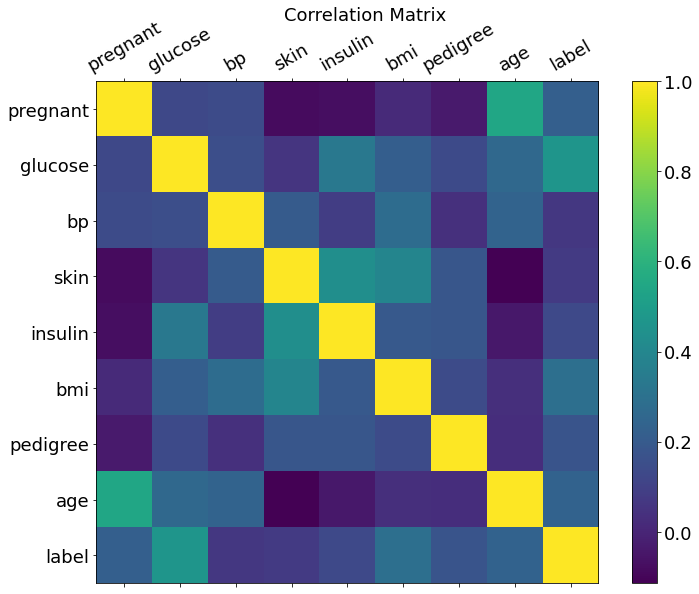

```python
f=plt.figure(figsize=(12, 9))
plt.matshow(pima.corr(), fignum=f.number)
plt.xticks(range(pima.shape[1]), pima.columns, fontsize=18, rotation=30)
plt.yticks(range(pima.shape[1]), pima.columns, fontsize=18)
cb = plt.colorbar()
cb.ax.tick_params(labelsize=18)
plt.suptitle('Correlation Matrix', fontsize=18);
```

## S.3.2 Train a Logistic Regression model on the Pima Diabetes Data Set

```python
# train the logistic regresssion model using our solver
parameters, losses, _,_ = logistic_regression(X_train, y_train, learning_rate=0.1,max_iter=1000, tol = 1.e-5)
w = parameters['weights']
b = parameters['bias']
```

### Check loss function convergence

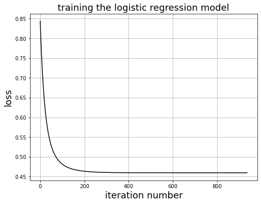

```
Model converged after 937 iterations
```

```python
# plot losses
plt.figure(figsize=(8, 6))
plt.plot(losses,'k-')
plt.title('training the logistic regression model',FontSize=18)
plt.xlabel('iteration number',FontSize=18)
plt.ylabel('loss',FontSize=18)
plt.grid()
plt.show()
print(f'Model converged after {len(losses)} iterations\n')
```

### Feature importances

The `weights` measure the feature importances and the direction of their association with the positive class  
We see that the most important feature is `glucose`, which we had expected from its relatively high correlation with the positive class.

```python
# logistic regression model summary
n_examples = np.size(X_test,axis=1)

# feature importances are the model weights
feature_importance_table = zip(feature_cols, w)
print('Feature importances are the model weights:\n')
[print(f'{feature}, {weight}') for (feature,weight) in feature_importance_table];
```

```
Feature importances are the model weights:

pregnant, [0.20596879]
glucose, [1.15086037]
bp, [-0.24387996]
skin, [0.0738748]
insulin, [-0.18375314]
bmi, [0.80026879]
pedigree, [0.16900717]
age, [0.4447354]
```

### Predict the class probabilities and the class labels for the held-out test set

Apply a decision threshold of 0.5 to the class probabilities

```python
# predict the class probabilities and labels for the  held-out test set
y_pred_proba = predict_y(X_test,w,b)
y_pred = y_pred_proba>0.5
```

### Check our results against scikit-learn's `sklearn LogisticRegressor`

*We find 100% agreement, which validates our code!*

```python
# instantiate model
logreg = LogisticRegression()

# fit model to our data
logreg.fit(X_train.T,np.squeeze(y_train))

# get sklern predictions
y_pred_sklearn=logreg.predict(X_test.T)

# compare
print(f'There is {100*sum(np.squeeze(y_pred) == y_pred_sklearn)/len(y_pred)} percent agreement between our model and the sklearn model')
```

```
There is 100.0 percent agreement between our model and the sklearn model
```

### Confusion matrix for the test set

The confusion matrix shows the numbers of correct and incorrect classifications of the positive and negative examples.  
Our model is pretty good (95 correct and 28 wrong) at predicting the *absence* of diabetes (class 0)  
Somewhat less good (45 correct and 24 wrong) at predicting the *presence* of diabetes (class 1)

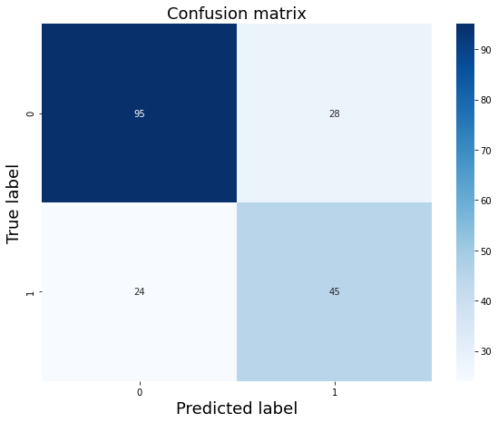

```python
# confusion matrix
cnf_matrix = metrics.confusion_matrix(y_test, y_pred)

# class labels
class_names=[0,1]

# set up the figure
fig, ax = plt.subplots(1,1,figsize=[8,6])
tick_marks = np.arange(len(class_names))
plt.xticks(tick_marks, class_names)
plt.yticks(tick_marks, class_names)

# plot the confusion matrix
sns.heatmap(pd.DataFrame(cnf_matrix), annot=True, cmap= 'Blues',fmt='g')
ax.xaxis.set_label_position("bottom")
plt.tight_layout()
plt.ylabel('True label',FontSize=18)
plt.xlabel('Predicted label',FontSize=18)
plt.title('Confusion matrix',FontSize=18);
```

### Performance metrics for the test set

*Accuracy* is the fraction of all examples that were correctly classified  
*Precision* is the fraction of positive detections that were actually in the positive class  
*Recall* is the fraction of positive examples that were correctly classified

```python
print(f'Accuracy: {metrics.accuracy_score(y_test, y_pred):.3}')
print(f'Precision: {metrics.precision_score(y_test, y_pred):.3}')
print(f'Recall: {metrics.recall_score(y_test, y_pred):.3}')
```

```
Accuracy: 0.729
Precision: 0.616
Recall: 0.652
```

### The ROC curve

**ROC** is the abbreviation for **Receiver Operating Characteristic**. The **ROC curve** is a plot of True positive Rate (**TPR**) as a function of False Positive Rate (**FPR**). It shows a model's detection capability as a function of decision threshold (**FPR** is a proxy for decision threshold).

If you set the decision threshold at zero (classify everything as positive), then the true positive rate (**TPR**) is $1$, since all the positives are correctly classified, and the **FPR** is also $1$ (since all the negative examples are misclassified as positives!). This is the top right of the **ROC curve** at $(1,1)$

On the other hand, if you set the decision threshold at 1, then no positive class is detected (no probability can be greater than 1), so the **TPR** is zero and the **FPR** is also zero (no positives were misclassified!). This is the point at the bottom left of the **ROC curve**, at $(0,0)$

### The AUC metric

A classifier's **AUC metric** is the area under the **ROC curve**. Its advantage is that it is independent of class imbalance.  
Formally, the **AUC metric** measures the probability that the model will rank a randomly chosen positive example higher than a randomly chosen negative example. In other words, the **AUC metric** gives the probability that the model will correctly classify a random pair of opposite-class examples.

For a perfect classifier, the **ROC** curve is a horizontal line at **TPR** = 1, and has **AUC** = 1

The worst possible classifier is based on random chance (i.e., classify each example by flipping a coin); the **ROC curve** is a diagonal line from (0,0) to (1,1) and has **AUC** of 0.50.

For a good classifier, the **ROC curve** bulges above the diagonal toward the line at **TPR** = 1, and the **AUC** is significantly higher than 0.5

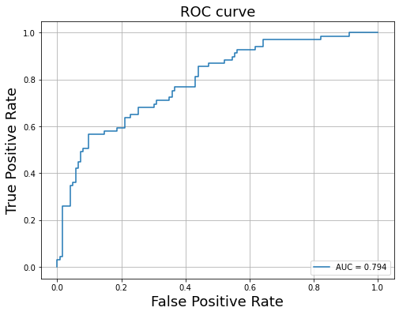

```python
FPR, TPR, _ = metrics.roc_curve(y_test, y_pred_proba)
AUC = metrics.roc_auc_score(y_test, y_pred_proba)
fig, ax = plt.subplots(figsize=[8,6])

plt.plot(FPR, TPR, label=f'AUC = {AUC:.3}')
plt.legend(loc='lower right')
plt.title('ROC curve',FontSize=18)
plt.xlabel('False Positive Rate',FontSize=18)
plt.ylabel('True Positive Rate',FontSize=18)
plt.grid()
plt.show()
```